# Exercício Computacional 6

Importando libraries:

```r
library(tidyverse)
```

Setando o diretório corrente:

```r
setwd(dirname(rstudioapi::getActiveDocumentContext()$path))
getwd()
```

```
[1] "/Users/adrianosastre/Dropbox/Data Science/Exercícios/datascience-exercises-20200418-conceitos-ml/Exercícios-Computacionais/6"
```

Conceito explorado: MSE - Mean Square Error

Considere o mesmo modelo de geração de dados do exercício anterior. O objetivo aqui é constatar o impacto do desvio padrão s sobre a performance do modelo proposto pelos cientistas de dados. Para isso, utilize a instrução abaixo, em linguagem R, para a geração de um vetor com diversos valores de desvio padrão para a incerteza Gaussiana retratada pelo termo e.

Para que seja possível explorar e visualizar o impacto de s - realize, pelo menos, 1000 iterações do algoritmo. Especificamente, para cada valor de desvio padrão avaliado, armazene e faça o cálculo da média aritmética sobre 1000 valores de performance expressos pelo MSE. Um dica é utilizar estruturas em loop (for) para a implementação das iterações.

1. Construa o modelo de geração de dados incluindo as iterações para cada valor de s

```r
# Número de amostras
n = 100
num_iter = 1000

# std_vector = seq(1,10,1)

# Vetor com valores de desvio-padrão entre 0 e 20
std_vector = seq(1, 20, length.out = 100)
std_vector
```

```
  [1]  1.000000  1.191919  1.383838  1.575758  1.767677  1.959596  2.151515  2.343434  2.535354  2.727273  2.919192
 [12]  3.111111  3.303030  3.494949  3.686869  3.878788  4.070707  4.262626  4.454545  4.646465  4.838384  5.030303
 [23]  5.222222  5.414141  5.606061  5.797980  5.989899  6.181818  6.373737  6.565657  6.757576  6.949495  7.141414
 [34]  7.333333  7.525253  7.717172  7.909091  8.101010  8.292929  8.484848  8.676768  8.868687  9.060606  9.252525
 [45]  9.444444  9.636364  9.828283 10.020202 10.212121 10.404040 10.595960 10.787879 10.979798 11.171717 11.363636
 [56] 11.555556 11.747475 11.939394 12.131313 12.323232 12.515152 12.707071 12.898990 13.090909 13.282828 13.474747
 [67] 13.666667 13.858586 14.050505 14.242424 14.434343 14.626263 14.818182 15.010101 15.202020 15.393939 15.585859
 [78] 15.777778 15.969697 16.161616 16.353535 16.545455 16.737374 16.929293 17.121212 17.313131 17.505051 17.696970
 [89] 17.888889 18.080808 18.272727 18.464646 18.656566 18.848485 19.040404 19.232323 19.424242 19.616162 19.808081
[100] 20.000000
```

```r
std_vector = sort(std_vector, decreasing = TRUE)
std_vector
```

```
  [1] 20.000000 19.808081 19.616162 19.424242 19.232323 19.040404 18.848485 18.656566 18.464646 18.272727 18.080808
 [12] 17.888889 17.696970 17.505051 17.313131 17.121212 16.929293 16.737374 16.545455 16.353535 16.161616 15.969697
 [23] 15.777778 15.585859 15.393939 15.202020 15.010101 14.818182 14.626263 14.434343 14.242424 14.050505 13.858586
 [34] 13.666667 13.474747 13.282828 13.090909 12.898990 12.707071 12.515152 12.323232 12.131313 11.939394 11.747475
 [45] 11.555556 11.363636 11.171717 10.979798 10.787879 10.595960 10.404040 10.212121 10.020202  9.828283  9.636364
 [56]  9.444444  9.252525  9.060606  8.868687  8.676768  8.484848  8.292929  8.101010  7.909091  7.717172  7.525253
 [67]  7.333333  7.141414  6.949495  6.757576  6.565657  6.373737  6.181818  5.989899  5.797980  5.606061  5.414141
 [78]  5.222222  5.030303  4.838384  4.646465  4.454545  4.262626  4.070707  3.878788  3.686869  3.494949  3.303030
 [89]  3.111111  2.919192  2.727273  2.535354  2.343434  2.151515  1.959596  1.767677  1.575758  1.383838  1.191919
[100]  1.000000
```

```r
MSE_vector = rep(0,length(std_vector))
MSE        = rep(0,num_iter)

# Crie um vetor de índices x variando de 0 a 100. Utilize a função seq - sequence
# x = seq(from = 0, to = 100, by = 1)
x = seq(1, 100, length.out = n)
x
```

```
  [1]   1   2   3   4   5   6   7   8   9  10  11  12  13  14  15  16  17  18  19  20  21  22  23  24  25  26  27
 [28]  28  29  30  31  32  33  34  35  36  37  38  39  40  41  42  43  44  45  46  47  48  49  50  51  52  53  54
 [55]  55  56  57  58  59  60  61  62  63  64  65  66  67  68  69  70  71  72  73  74  75  76  77  78  79  80  81
 [82]  82  83  84  85  86  87  88  89  90  91  92  93  94  95  96  97  98  99 100
```

```r
# Função hipótese verdadeira
h_x <- 3*x + 30
h_x
```

```
  [1]  33  36  39  42  45  48  51  54  57  60  63  66  69  72  75  78  81  84  87  90  93  96  99 102 105 108 111
 [28] 114 117 120 123 126 129 132 135 138 141 144 147 150 153 156 159 162 165 168 171 174 177 180 183 186 189 192
 [55] 195 198 201 204 207 210 213 216 219 222 225 228 231 234 237 240 243 246 249 252 255 258 261 264 267 270 273
 [82] 276 279 282 285 288 291 294 297 300 303 306 309 312 315 318 321 324 327 330
```

```r
for (k in 1:length(std_vector)){

  for (i in 1:num_iter){

    # Ruído
    epsilon <- rnorm(n, 0, std_vector[k])

    # Variável de saída
    y <- h_x + epsilon

    # Função hipótese Estimada
    h_x_estimado <- 2.8*x + 32

    # Erro quadrático médio para uma iteração
    MSE[i] = (1/n)*sum(((y - h_x_estimado)^2))
  }


  # Erro quadrático médio para várias iterações
  MSE_vector[k] = mean(MSE)
}
```

2. Faça um gráfico que mostra o impacto de s, colocado sobre o eixo x, sobre o desempenho indicado pelo MSE, apresentado no eixo y.

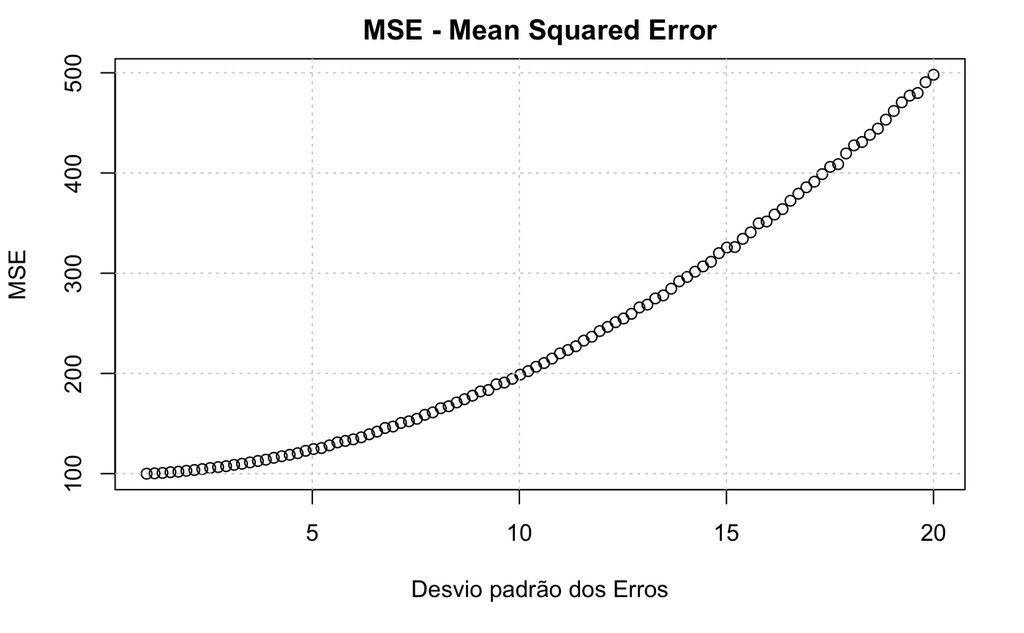

```r
plot(std_vector,MSE_vector,col=1, pch=1, main = 'MSE - Mean Squared Error',
     col.main = 'black',
     xlab = 'Desvio padrão dos Erros',
     ylab = 'MSE')
grid()
```

3. Faça uma análise: o impacto com o aumento ou redução de s é significativo para o modelo? Qual a justificativa?

RESPOSTA = O erro aumenta com o aumento de s.